# Codificación de señales digitales

Julio César Ramirez-Pacheco, UQroo Unidad Cancún

15/09/2022

## El concepto de codificación

La codificación de señales permite modificar características de la señal de información para adaptarlas al canal de comunicación. La codificación de puede realizar de señales digitales a digitales, de señales digitales a analógicas, y de señales analógicas a analógicas. En esta práctica nos concentraremos en la codificación de señales digitales a digitales y usualmente podemos encontrar los siguientes tipos de codificación:

- NRZ-I.
- NRZ-L.
- AMI bipolar.
- Pseudoternario.
- Manchester.
- Manchester diferencial.
- B8ZS.
- HDB3.

El propósito de la siguiente práctica es generar todas las codificaciones usando el lenguaje de programación R. Iniciaremos generando la señal de información y posteriormente codificar usando NRZ-L. La generación de la señal de información se realiza de la siguiente manera:

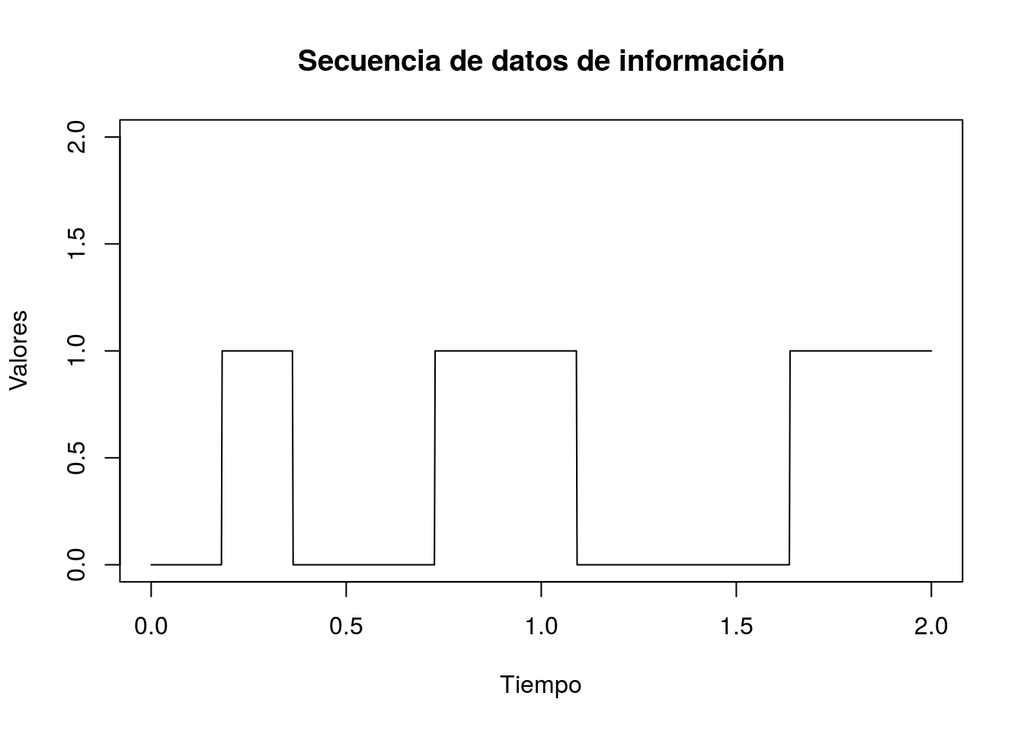

```r
# Información original 01001100011
# Representación gráfica
xt <- c(0,1,0,0,1,1,0,0,0,1,1)
bits <- rep(xt, each=100)
time <- seq(0,2, length=length(bits))
plot(time, bits, type = "l",
main="Secuencia de datos de información", xlab="Tiempo", ylab="Valores", ylim=c(0,2))
```

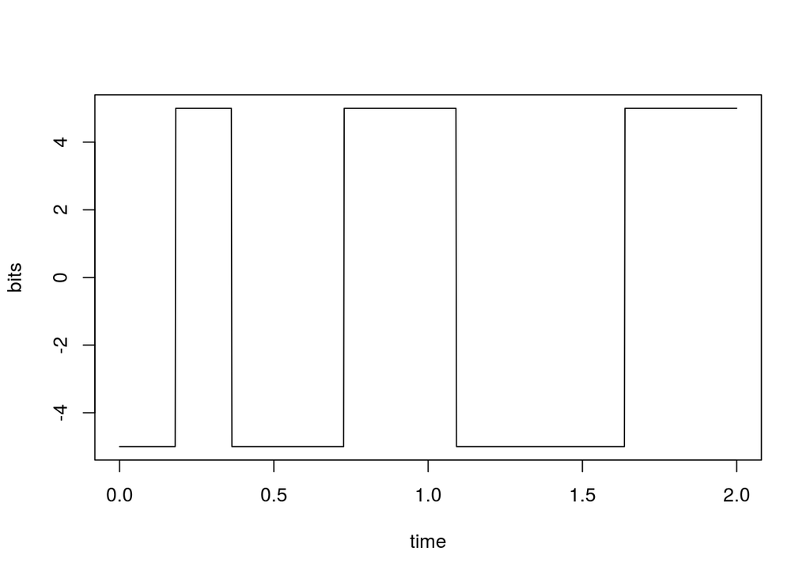

```r
xt <- c(0,1,0,0,1,1,0,0,0,1,1)         # Se generan los códigos
# Ahora se codifica de acuerdo a la regla descrita arriba
nrzl <- ifelse(xt>0, 5, -5)
bits <- rep(nrzl, each=100)
time <- seq(0,2, length=length(bits))  # Se genera el tiempo (puede ser cualquiera).
plot(time, bits, type = "l")
```

## NRZ-I

Si ahora queremos codificar con NRZ-I, entonces tenemos:

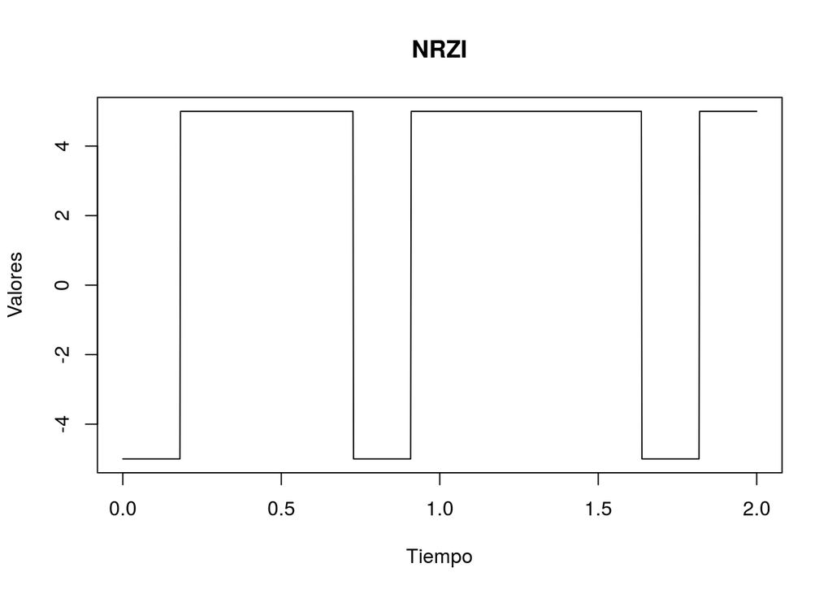

```r
xt <- c(0,1,0,0,1,1,0,0,0,1,1)         # Se generan los códigos
# Ahora se codifica de acuerdo a la regla del NRZ-I
nrzi <- NULL
memory <- 0
for(i in 1:length(xt)){
  if(xt[i] == 0 && memory == 0){
    nrzi[i] <- 0
    memory  <- 0
  }
  else if(xt[i]==0 && memory ==1){
    nrzi[i] <- 1
    memory  <- 1
  }
  else if(xt[i] == 1 && memory == 0){
    nrzi[i] <- 1
    memory  <- 1
  }
  else{
    nrzi[i] <- 0
    memory  <- 0
  }
}
nrzi_polar <- ifelse(nrzi==0,-5,5)
bits <- rep(nrzi_polar, each=100)
time <- seq(0,2, length=length(bits))  # Se genera el tiempo (puede ser cualquiera).
plot(time, bits, type= "l", main="NRZI", xlab="Tiempo", ylab="Valores")
```

## Tareas

1. Implementar la codificación AMI bipolar.
2. Pseudoternaria.
3. Manchester.
4. Manchester diferencial.
5. B8ZS.
6. HDB3.